# 探索的因子分析

tomokoba

2020-01-01

科学において測定は重要である。心理学においては、目に見えない心の働きを研究するうえで様々な質問項目が利用されてきており、それがお家芸にもなっている。複数からなる質問項目がいったいどのような概念を表しているのかは関心の高いところであるが、探索的因子分析は項目への回答に影響した因子の存在を統計的に抽出する手法である。

Rで分析する場合には以下のコードを用いる。

```r
data <- XXX #分析したいデータを入れる

library(psych) #psychパッケージを使う

#因子数の決定
va<-data.frame(data$Q1,data$Q2,data$Q3,data$Q4,data$Q5,data$Q6,data$Q7,data$Q8,data$Q9,data$Q10,data$Q11) #因子分析にかける変数を取り出す

fa.parallel(va) #推定される最大の因子数（平行分析）
VSS(va,plot=FALSE)　#推定される最小の因子数（最小平均偏相関）


#探索的因子分析
fa.result <- fa(va, nfactors = 4, fm = "minres", rotate = "promax")　#たとえば因子数を4として、最小二乗法のプロマックス、どーん!
print(fa.result, sort = T, digit = 3, cut=0.3) #結果の表示。ソートかけて、桁数は3、0.3以下の結果はカット
```

上のコードでは、回転法はプロマックス回転、初期解の算出には最小二乗法を用いている。  
回転法（rotate=）については直交回転と斜交回転を選択できる。直交回転なら“varimax”、斜交回転なら“promax”が使えるが、その他の回転法も直交回転と斜交回転のそれぞれ用意されている。  
初期解の算出（fm=）には、最小二乗法なら“minres”、最尤法なら“ml”、主因子法なら“pa”が使える。他にもあり。

### 因子数の選定

因子分析をするにあたってはまず因子数の選定が必要になってくる。基本的には理論的な説明が可能であることが大切だろうが、統計的な算出方法もある。有名なのはスクリープロットでかくんとなってるところを基準に見るやつ。  
その他、平行分析と最小平均偏相関という手法がある（どちらもpsychoパッケージに入ってる）。数学的なことはわからないけど、平行分析は因子数として選定され得る数を大きめに出す。一方、最小平均偏相関は因子数を倹約的に推定する。そのため、因子数はだいたい最小平均偏相関の値から平行分析の値までの間で分析していって、理論的な説明や因子分析のモデル適合度を見ながら最終的な因子数を決めるのが良さそう。  
データセットとしてpsychパッケージに入っている“epi.bfi”を使用する。このデータセットにはアイゼンク性格検査（EPI）とBig 5尺度、ベック抑うつ性尺度、特性‐状態不安の得点が231人分入っている。

```r
library(psych) #psychパッケージを使う

va<-epi.bfi #因子分析にかける変数を取り出す。ここではすべての変数を使う。
```

- 平行分析

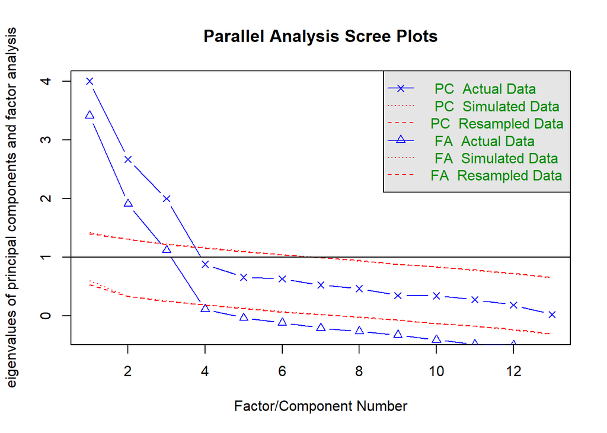

```
## Parallel analysis suggests that the number of factors =  3  and the number of components =  3
```

```r
fa.parallel(va) #推定される最大の因子数（平行分析）
```

- 最小平均偏相関

“The Velicer MAP achieves a minimum of 0.05 with…”のところのfactorsを見る。

```r
VSS(va,plot=FALSE)　#推定される最小の因子数（最小平均偏相関）
```

```
##
## Very Simple Structure
## Call: vss(x = x, n = n, rotate = rotate, diagonal = diagonal, fm = fm,
##     n.obs = n.obs, plot = plot, title = title, use = use, cor = cor)
## VSS complexity 1 achieves a maximimum of 0.73  with  3  factors
## VSS complexity 2 achieves a maximimum of 0.86  with  3  factors
##
## The Velicer MAP achieves a minimum of 0.05  with  3  factors
## BIC achieves a minimum of  -22.79  with  6  factors
## Sample Size adjusted BIC achieves a minimum of  -3.74  with  8  factors
##
## Statistics by number of factors
##   vss1 vss2   map dof   chisq     prob sqresid  fit RMSEA BIC  SABIC complex
## 1 0.53 0.00 0.098  65 1253.38 2.0e-219    14.0 0.53 0.286 900 1105.6     1.0
## 2 0.70 0.76 0.076  53  704.54 1.2e-114     7.0 0.76 0.235 416  584.1     1.1
## 3 0.73 0.86 0.050  42  354.38  4.8e-51     3.1 0.90 0.183 126  258.9     1.3
## 4 0.71 0.86 0.065  32  262.74  4.6e-38     2.5 0.92 0.181  89  190.0     1.5
## 5 0.65 0.84 0.088  23  142.11  3.8e-19     2.1 0.93 0.153  17   89.8     1.7
## 6 0.63 0.85 0.116  15   58.85  4.0e-07     1.8 0.94 0.116 -23   24.8     1.7
## 7 0.66 0.83 0.147   8   21.71  5.5e-03     1.7 0.94 0.089 -22    3.5     1.8
## 8 0.65 0.81 0.218   2    0.81  6.7e-01     1.3 0.96 0.000 -10   -3.7     1.7
##    eChisq    SRMR eCRMS eBIC
## 1 1.5e+03 0.20267 0.222 1126
## 2 4.9e+02 0.11719 0.142  206
## 3 5.6e+01 0.03932 0.054 -173
## 4 2.8e+01 0.02811 0.044 -146
## 5 1.4e+01 0.01940 0.036 -112
## 6 3.3e+00 0.00952 0.022  -78
## 7 7.7e-01 0.00461 0.014  -43
## 8 1.5e-02 0.00065 0.004  -11
```

### 探索的因子分析

因子数は３因子が良さそう。

```r
fa.result <- fa(va, nfactors = 3, fm = "minres", rotate = "promax")　#因子数を3として、最小二乗法のプロマックス、どーん!
print(fa.result, sort = T, digit = 3, cut=0.3) #結果の表示。ソートかけて、桁数は3、0.3以下の結果はカット
```

```
## Factor Analysis using method =  minres
## Call: fa(r = va, nfactors = 3, rotate = "promax", fm = "minres")
##
##  Warning: A Heywood case was detected.
## Standardized loadings (pattern matrix) based upon correlation matrix
##          item    MR1    MR2    MR3    h2      u2  com
## epiNeur     5  0.828               0.663  0.3371 1.05
## traitanx   12  0.825               0.821  0.1793 1.15
## bfneur      9  0.821         0.334 0.643  0.3566 1.33
## bdi        11  0.718               0.534  0.4663 1.01
## stateanx   13  0.662               0.451  0.5487 1.01
## epilie      4                      0.187  0.8125 2.39
## epiE        1         1.015        1.050 -0.0497 1.02
## epiImp      3         0.757        0.568  0.4319 1.07
## epiS        2         0.702        0.584  0.4165 1.20
## bfagree     6                0.646 0.449  0.5512 1.03
## bfopen     10                0.642 0.404  0.5963 1.23
## bfcon       7                0.639 0.464  0.5359 1.35
## bfext       8         0.481  0.613 0.685  0.3155 1.90
##
##                         MR1   MR2   MR3
## SS loadings           3.127 2.541 1.834
## Proportion Var        0.241 0.195 0.141
## Cumulative Var        0.241 0.436 0.577
## Proportion Explained  0.417 0.339 0.244
## Cumulative Proportion 0.417 0.756 1.000
##
##  With factor correlations of
##        MR1    MR2    MR3
## MR1  1.000 -0.010 -0.257
## MR2 -0.010  1.000  0.117
## MR3 -0.257  0.117  1.000
##
## Mean item complexity =  1.3
## Test of the hypothesis that 3 factors are sufficient.
##
## The degrees of freedom for the null model are  78  and the objective function was  8.247 with Chi Square of  1854.125
## The degrees of freedom for the model are 42  and the objective function was  1.59
##
## The root mean square of the residuals (RMSR) is  0.039
## The df corrected root mean square of the residuals is  0.054
##
## The harmonic number of observations is  231 with the empirical chi square  55.713  with prob <  0.0764
## The total number of observations was  231  with Likelihood Chi Square =  354.378  with prob <  4.81e-51
##
## Tucker Lewis Index of factoring reliability =  0.6703
## RMSEA index =  0.1831  and the 90 % confidence intervals are  0.1628 0.1973
## BIC =  125.797
## Fit based upon off diagonal values = 0.985
```